# Section 5: Inference for genomics with Bioconductor

Haeun Lee

2026-01-23

```r
BiocManager::install(c("SpikeInSubset",
                       "genefilter",
                       "qvalue",
                       "limma",
                       "genomicsclass/maPooling",
                       "leukemiasEset",
                       "preprocessCore"))
```

```
## Bioconductor version 3.16 (BiocManager 1.30.27), R 4.2.3 (2023-03-15)
```

```
## Installing github package(s) 'genomicsclass/maPooling'
```

```
## Skipping install of 'maPooling' from a github remote, the SHA1 (489b3c73) has not changed since last install.
##   Use `force = TRUE` to force installation
```

[output not shown]

# Differential expression and multiple comparisons

## Statistical prerequisites

## Biological versus technical variability

The t-test takes into account within population variability. In experimental biology, this variability can be divided into two main classes: technical and biological.

## t-tests in genomics

```r
library(genefilter)
# rowttests(assay_data, grouping_factor)
```

## Moderated t-tests with the limma package

Three steps in the basic limma analysis: - lmFit() to fit linear models - eBayes() to perform hierarchical modeling - topTable() to return the top features

### Assessment

```r
BiocManager::install("genomicsclass/maPooling")
library(Biobase)
library(maPooling)
data(maPooling)
pd=pData(maPooling)
pooled=which(rowSums(pd)==12)
individuals=which(rowSums(pd)==1)
##remove replicates
individuals=individuals[-grep("tr",names(individuals))]
pool = exprs(maPooling)[,pooled] # from maPooling@assayData
indiv = exprs(maPooling)[,individuals] # from maPooling@assayData
strain = ifelse(grepl("a",rownames(pData(maPooling))),0,1)

g_pool = strain[pooled]
g_indiv = strain[individuals]

technicalsd <- rowSds(pool[,g_pool==1])
biologicalsd <- rowSds(indiv[,g_indiv==1])

mean(biologicalsd>technicalsd)
```

```
## [1] 0.7994725
```

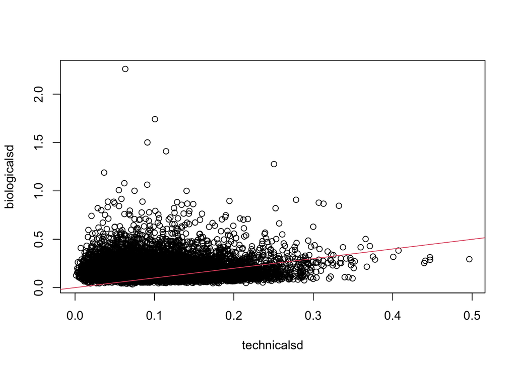

```r
## plot
plot(technicalsd,biologicalsd)
abline(0,1,col=2)
```

```r
tt = rowttests(pool,factor(g_pool))
library(qvalue)
qvals = qvalue(tt$p.value)$qvalue
sum(qvals < 0.05)
```

```
## [1] 2169
```

```r
i = which(qvals < 0.05)

# Much larger than we expected given that we estimated an FDR of 5% in the first list. This is because the pooled data is not accounting for biological variability.
pvals_ind = rowttests(indiv,factor(g_indiv))$p.value
mean(pvals_ind[i]>0.05)
```

```
## [1] 0.2784693
```

```r
qvals_ind = qvalue(pvals_ind)$qvalue
i_ind = which(qvals_ind < 0.05)

library(limma)
fit <- lmFit(indiv, design=model.matrix(~ g_indiv))
fit <- eBayes(fit)

qval_modt = qvalue(fit$p.value[,2])$qvalue
## qval_modt = qvalue(fit$p.value)$qvalue[,2] --> this give another value!
# all p-values from all columns are used >> one global π₀ is estimated from the full set

mean(qval_modt[i_ind]<0.05)
```

```
## [1] 0.9889737
```

```r
# Among the indices in i_ind, what fraction are significant under qval_modt?
# depends on the size of i_ind

## i_ind_modt = which(qval_modt < 0.05)
## mean(i_ind_modt %in% i_ind)
# Among the discoveries from qval_modt, what fraction are also in i_ind?
# depends on the size of i_ind_modt

# Note that we get very strong agreement because N is 12 here and thus the standard error estimates are not shrunk too much.
```

# Gene set analysis: inference on coordinated expression changes

Testing for differences in predefined sets of genes between sample groups

## Summary statistics for gene sets

The t-statistics from individual genes within a gene set can have positive, 0, or negative correlation.

The t-statistics can have any kind of positive, 0, or negative correlation, depending on the nature of the experiment and the genes in the set. Positive correlations can occur for example in the case of batch effects. If the genes in a set are similarly affected by batch, and batch effects are not corrected for, then a high t-statistic for one gene means that a high t-statistic for the other gene is more likely. Positive correlation can also occur, for example if one gene positively regulates the other gene (in terms of gene regulatory networks). Genes within a set can also potentially have a negative correlation if one gene in a set is a negative regulator of another gene in the set. This variation could then lead to a negative correlation between the expression of these two genes, and therefore a negative correlation between the two t-statistics.

## Hypothesis testing for gene sets

In real workflows: • limma → t-statistics → CAMERA • DESeq2 → Wald stats → GSEA • edgeR → likelihood ratio stats → ROAST

## Gene set testing in R part I: Applying the roast algorithm for a single gene set

## Gene set testing in R part II

# Verified assessment

## Q3: Exploring dependence

```r
var(rowMeans(matrix(rnorm(10000 * 10, 0, 1), ncol=10)))
```

```
## [1] 0.1011325
```

```r
library(MASS)
# 10 Normal variables with mean 0 and variance 1, but each random variable has a correlation of 0.7 with the other variables. We can create such random variables in R using the multivariate normal distribution:
Sigma = matrix(.7, ncol=10, nrow=10)
diag(Sigma) = 1
mvrnorm(n=1,mu=rep(0,10),Sigma=Sigma)
```

```
##  [1]  0.48645078 -0.42201244  1.40805099  0.70501313  0.95009806  0.03856352
##  [7]  0.87856244 -0.07340335  0.30494415  0.07208053
```

$$\begin{eqnarray}
Var(\bar{t}) &=& \frac{1}{N^2} \mbox{var}( (1 \dots 1) (t_1
\dots
t_N)' ) \\
&=& \frac{1}{N^2}(1 \dots 1)
\begin{pmatrix}
1 & \rho & \dots & \rho & \rho \\
\rho & 1 & \rho & \dots & \rho \\
\dots & \dots & \dots & \dots & \dots \\
\rho & \rho & \dots & \rho & 1 \\
\end{pmatrix}
(1 \dots 1) ' \\
&=& \frac{1}{N^2}\{N + (N-1) N \rho \} \\
&=& \frac{1}{N}\{1 + (N-1) \rho \} \\
\end{eqnarray}$$

```r
avgcorrs = 1/10 * (1 + (10 - 1) * 0.7) # variance of the average of these 10 random variables

##Using simulation:
set.seed(2)
var(rowMeans(mvrnorm(n=10000,mu=rep(0,10),Sigma=Sigma)))
```

```
## [1] 0.7295269
```

## Q4: Gene set analysis with the roast algorithm

```r
library(GEOquery)
e = getGEO("GSE34313")[[1]]
```

```
## Found 1 file(s)
```

```
## GSE34313_series_matrix.txt.gz
```

```r
e$condition = as.factor(e$characteristics_ch1.2)
levels(e$condition) = c("dex24","dex4","control")
table(e$condition)
```

```
##
##   dex24    dex4 control
##       3       3       4
```

```r
## Note that with ExpressionSets we can access the phenoData columns directly
## Specifically, note that e$condition is equivalent to pData(e)$condition

names(fData(e))
```

```
##  [1] "ID"                   "SPOT_ID"              "CONTROL_TYPE"
##  [4] "REFSEQ"               "GB_ACC"               "GENE"
##  [7] "GENE_SYMBOL"          "GENE_NAME"            "UNIGENE_ID"
## [10] "ENSEMBL_ID"           "TIGR_ID"              "ACCESSION_STRING"
## [13] "CHROMOSOMAL_LOCATION" "CYTOBAND"             "DESCRIPTION"
## [16] "GO_ID"                "SEQUENCE"
```

```r
fData(e)$GO_ID[1:4] # data includes GO terms for every gene
```

```
## [1] "GO:0016020(membrane)|GO:0016021(integral to membrane)"
## [2] "GO:0005794(Golgi apparatus)|GO:0006886(intracellular protein transport)|GO:0008565(protein transporter activity)|GO:0016020(membrane)|GO:0016192(vesicle-mediated transport)|GO:0030117(membrane coat)|GO:0030659(cytoplasmic vesicle membrane)|GO:0031410(cytoplasmic vesicle)"
## [3] "GO:0001669(acrosomal vesicle)|GO:0006836(neurotransmitter transport)|GO:0016020(membrane)|GO:0016021(integral to membrane)|GO:0022857(transmembrane transporter activity)|GO:0030054(cell junction)|GO:0030672(synaptic vesicle membrane)|GO:0031410(cytoplasmic vesicle)|GO:0045202(synapse)"
## [4] "GO:0000166(nucleotide binding)|GO:0003676(nucleic acid binding)"
```

```r
# compare the control samples to those treated with dexamethasone (the hormone) after 4 hours
lvls = c("control", "dex4")
es = e[,e$condition %in% lvls]
es$condition = factor(es$condition, levels=lvls)

library(limma)
library(qvalue)
design = model.matrix(~ es$condition)
fit = lmFit(es, design=design)
fit = eBayes(fit)
topTable(fit)[,c(6,7,18,22)]
```

```
## Removing intercept from test coefficients
```

```
##               GENE GENE_SYMBOL     logFC    adj.P.Val
## A_23_P133408  1437        CSF2 -4.724965 6.248554e-08
## A_24_P122137  3976         LIF -6.689927 6.248554e-08
## A_32_P5276   26084    ARHGEF26  3.411468 1.744514e-07
## A_23_P89431   6347        CCL2 -3.618725 1.744514e-07
## A_23_P42257   8870        IER3 -4.808854 3.294838e-07
## A_23_P71037   3569         IL6 -4.568355 4.212726e-07
## A_24_P20327  28999       KLF15  4.013070 4.212726e-07
## A_24_P38081   2289       FKBP5  3.567059 4.212726e-07
## A_23_P213944  1839       HBEGF -2.902190 4.212726e-07
## A_24_P250922  5743       PTGS2 -3.518360 4.727798e-07
```

Top genes are common immune-response genes (CSF2, LIF, CCL2, IL6). Also present is FKBP5, a gene which regulates and is regulated by the protein which receives the glucocorticoid hormone

ROAST method for gene set testing We can test a single gene set by looking up the genes which contain a certain GO ID, and providing this to the roast() function.

The roast function performs an advanced statistical technique, rotation of residuals, in order to generate a sense of the null distribution for the test statistic. The test statistic in this case is the summary of the scores from each gene. The tests are self-contained because only the summary for a single set is used, whereas other gene set tests might compare a set to all the other genes in the dataset, e.g., a competitive gene set test.

The result here tells us that the *immune response* genes are significantly down-regulated, and additionally, mixed up and down.

```r
# Immune response
set.seed(1)
idx = grep("GO:0006955", fData(es)$GO_ID)
length(idx)
```

```
## [1] 504
```

```r
r1 = roast(es, idx, design)
r1
```

```
##          Active.Prop    P.Value
## Down      0.16269841 0.01925481
## Up        0.09325397 0.98099525
## UpOrDown  0.16269841 0.03850000
## Mixed     0.25595238 0.01700000
```

```r
set.seed(2)
idx2 = grep("GO:0045454", fData(es)$GO_ID)
length(idx2)
```

```
## [1] 81
```

```r
r2 = roast(es, idx2, design)
r2
```

```
##          Active.Prop    P.Value
## Down      0.08641975 0.92248062
## Up        0.23456790 0.07776944
## UpOrDown  0.23456790 0.15550000
## Mixed     0.32098765 0.01400000
```

```r
r2[1]$p.value$P.Value[1]
```

```
## [1] 0.9224806
```

## Q5: Inference for multiple gene sets

We can also use the mroast() function to perform multiple roast tests. First we need to create a list, which contains the indices of genes in the ExpressionSet for each of a number of gene sets. We will use the org.Hs.eg.db package to gather the gene set information. The following code used R to extracts and organizes GO annotations from a somewhat messy annotation provided by the manufacturer.

```r
library(org.Hs.eg.db)
org.Hs.egGO2EG
```

```
## GO2EG map for Human (object of class "Go3AnnDbBimap")
```

```r
go2eg = as.list(org.Hs.egGO2EG)
head(go2eg)
```

```
## $`GO:0000002`
##     TAS     IMP     ISS     IMP     IMP     NAS     IMP     IBA     IDA     IEA
##   "291"  "1890"  "4205"  "4358"  "4976"  "9361" "10000" "55186" "55186" "80119"
##     IBA     IDA     IMP
## "84275" "84275" "92667"
##
## $`GO:0000003`
##      IBA      IBA      IEP      IBA
##   "2796"   "2797"   "8510" "286826"
##
## $`GO:0000012`
##         IDA         IDA         IDA         IDA         IEA         IMP
##      "1161"      "2074"      "3981"      "7141"      "7515"     "23411"
##         IBA         IDA         IBA         IDA         IMP         IMP
##     "54840"     "54840"     "55775"     "55775"     "55775"    "200558"
##         IEA
## "100133315"
##
## $`GO:0000017`
##    IDA    IMP    ISS    IDA
## "6523" "6523" "6523" "6524"
##
## $`GO:0000018`
##     TAS     TAS     TAS     IMP     IMP     IEP
##  "3575"  "3836"  "3838"  "9984" "10189" "56916"
##
## $`GO:0000019`
##     TAS     IDA
##  "4361" "10111"
```

The following code unlists the list, then gets matches for each Entrez gene ID to the index in the ExpressionSet. Finally, we rebuild the list.

```r
govector = unlist(go2eg)
golengths = sapply(go2eg, length)
head(fData(es)$GENE) # Entrez gene identifiers
```

```
## [1] 400451  10239   9899 348093  57099 146050
```

```r
idxvector = match(govector, fData(es)$GENE);table(is.na(idxvector))
```

```
##
##  FALSE   TRUE
## 328834  19282
```

```r
##This is the organized list of indexes for genes per GO term:
idx = split(idxvector, rep(names(go2eg), golengths))
##We can see the genes like this:
go2eg[[1]]
```

```
##     TAS     IMP     ISS     IMP     IMP     NAS     IMP     IBA     IDA     IEA
##   "291"  "1890"  "4205"  "4358"  "4976"  "9361" "10000" "55186" "55186" "80119"
##     IBA     IDA     IMP
## "84275" "84275" "92667"
```

```r
fData(es)$GENE[idx[[1]]]
```

```
##  [1]   291  1890  4205  4358  4976  9361 10000 55186 55186 80119 84275 84275
## [13] 92667
```

We need to clean this list such that there are no NA values. We also clean it to remove gene sets which have less than 10 genes.

```r
idxclean = lapply(idx, function(x) x[!is.na(x)])
idxlengths = sapply(idxclean, length)
idxsub = idxclean[idxlengths > 10]
length(idxsub)
```

```
## [1] 4507
```

With these indexes in place we are now ready to run mroast. The following line of code runs the multiple ROAST test. This can take about 3 minutes.

```r
set.seed(1)
r2 = mroast(es, idxsub, design)
head(r2)
```

```
##            NGenes  PropDown     PropUp Direction PValue         FDR
## GO:0005391     21 0.0000000 0.61904762        Up  5e-04 0.006589181
## GO:0061578     23 0.6086957 0.04347826      Down  5e-04 0.006589181
## GO:0060045     23 0.5652174 0.17391304      Down  5e-04 0.006589181
## GO:0008532     11 0.0000000 0.54545455        Up  5e-04 0.006589181
## GO:0010273     13 0.0000000 0.53846154        Up  5e-04 0.006589181
## GO:0046599     13 0.5384615 0.23076923      Down  5e-04 0.006589181
##            PValue.Mixed   FDR.Mixed
## GO:0005391        5e-04 0.001691817
## GO:0061578        5e-04 0.001691817
## GO:0060045        5e-04 0.001691817
## GO:0008532        5e-03 0.020624518
## GO:0010273        5e-04 0.001691817
## GO:0046599        5e-04 0.001691817
```

Find the GO term that has the the largest proportion of upregulated genes. How many genes does this term have?

```r
r2[order(r2$PropUp, decreasing = TRUE), ]
```

```
##            NGenes    PropDown      PropUp Direction PValue         FDR
## GO:0042555     21 0.047619048 0.761904762        Up 0.0065 0.075519437
## GO:0000445     11 0.181818182 0.727272727        Up 0.0725 0.373858496
## GO:0008131     11 0.090909091 0.636363636        Up 0.0035 0.048825833
## GO:0005391     21 0.000000000 0.619047619        Up 0.0005 0.006589181
## GO:0047499     15 0.066666667 0.600000000        Up 0.0190 0.167008399
## GO:0008499     19 0.000000000 0.578947368        Up 0.0100 0.105127392
## GO:0003836     14 0.071428571 0.571428571        Up 0.0040 0.052981975
## GO:0008532     11 0.000000000 0.545454545        Up 0.0005 0.006589181
## GO:1903140     11 0.090909091 0.545454545        Up 0.0095 0.101434915
## GO:0032133     11 0.000000000 0.545454545        Up 0.0460 0.285193983
## GO:0044597     11 0.000000000 0.545454545        Up 0.0705 0.370745609
## GO:0010273     13 0.000000000 0.538461538        Up 0.0005 0.006589181
## GO:0051315     15 0.066666667 0.533333333        Up 0.0200 0.172506298
## GO:0071294     32 0.000000000 0.531250000        Up 0.0005 0.006589181
## GO:0061665     17 0.058823529 0.529411765        Up 0.0100 0.105127392
## GO:0035999     23 0.000000000 0.521739130        Up 0.0375 0.254372348
## GO:0008631     18 0.111111111 0.500000000        Up 0.0005 0.006589181
## GO:0004740     14 0.285714286 0.500000000        Up 0.0005 0.006589181
## GO:0031123     12 0.250000000 0.500000000        Up 0.0005 0.006589181
## GO:0046325     14 0.000000000 0.500000000        Up 0.0010 0.015944575
## GO:0035459     12 0.166666667 0.500000000        Up 0.0020 0.031052165
## GO:0030311     12 0.000000000 0.500000000        Up 0.0020 0.031052165
## GO:0000828     18 0.000000000 0.500000000        Up 0.0075 0.084652202
## GO:0032958     12 0.166666667 0.500000000        Up 0.0105 0.108443075
## GO:0030174     14 0.000000000 0.500000000        Up 0.0345 0.243094094
## GO:0044598     12 0.000000000 0.500000000        Up 0.0535 0.313312990
## GO:0001881     12 0.083333333 0.500000000        Up 0.0630 0.345738692
## GO:0005658     14 0.000000000 0.500000000        Up 0.0985 0.437130059
## GO:0031262     12 0.000000000 0.500000000        Up 0.1100 0.464890273
## GO:0005890     31 0.000000000 0.483870968        Up 0.0005 0.006589181
## GO:0071162     21 0.095238095 0.476190476        Up 0.0290 0.217409815
## GO:0045926     17 0.117647059 0.470588235        Up 0.0005 0.006589181
## GO:0004033     17 0.000000000 0.470588235        Up 0.0190 0.167008399
## GO:0004726     15 0.000000000 0.466666667        Up 0.0050 0.061873555
## GO:0051256     15 0.000000000 0.466666667        Up 0.0700 0.368970951
## GO:2000145     15 0.266666667 0.466666667        Up 0.1260 0.489848963
## GO:0006552     15 0.066666667 0.466666667        Up 0.1825 0.578451232
## GO:0045616     13 0.076923077 0.461538462        Up 0.0005 0.006589181
## GO:0048745     13 0.153846154 0.461538462        Up 0.0010 0.015944575
```

[output cut: 8961 more lines]

```
## GO:0001527       0.5935 0.632996626
## GO:0005832       0.7305 0.754524702
## GO:0015193       0.8960 0.903973410
## GO:0006556       0.6760 0.705491140
## GO:0050909       0.8590 0.869163766
## GO:0051006       0.8610 0.870992423
## GO:0140007       0.8370 0.849759407
## GO:0030123       0.4145 0.479338832
## GO:0004517       0.9855 0.985687403
## GO:0140036       0.5735 0.617209209
## GO:0061136       0.5755 0.618476085
## GO:0032446       0.3895 0.457576878
## GO:0036435       0.5470 0.595074197
## GO:0032784       0.4945 0.548261076
## GO:0048251       0.5900 0.630905115
```

```r
r2[which.max(r2$PropUp),1]
```

```
## [1] 21
```

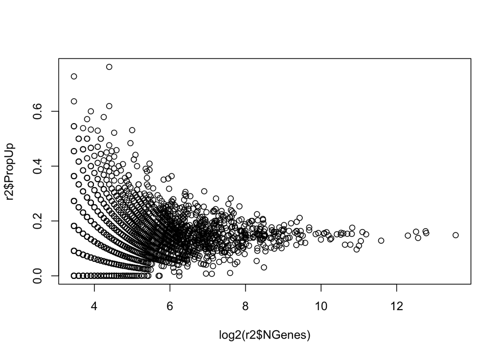

```r
# Note that this is a relatively small gene set. In fact, we can see that there is much more variability in this proportion for smaller gene sets:
plot(log2(r2$NGenes),r2$PropUp)
```

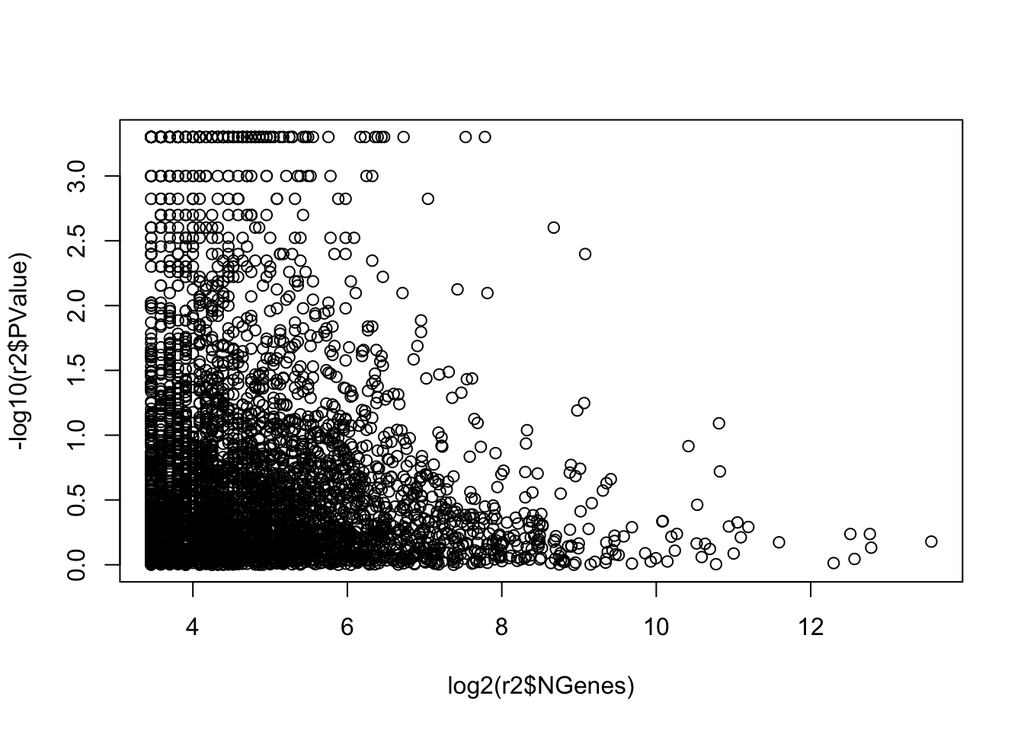

```r
plot(log2(r2$NGenes),-log10(r2$PValue))
```

## Q6: Filtering gene sets

```r
idxsub2 = idxclean[idxlengths >= 50]
length(idxsub2)
```

```
## [1] 945
```

```r
set.seed(2)
r3 = mroast(es, idxsub2, design)
head(r3)
```

```
##            NGenes  PropDown     PropUp Direction PValue      FDR PValue.Mixed
## GO:0008543     87 0.3448276 0.12643678      Down  5e-04 0.023625        5e-04
## GO:0005125    220 0.3045455 0.05000000      Down  5e-04 0.023625        5e-04
## GO:0008083    185 0.3027027 0.07567568      Down  5e-04 0.023625        5e-04
## GO:0071347     82 0.2926829 0.06097561      Down  5e-04 0.023625        5e-04
## GO:0042531     75 0.2666667 0.06666667      Down  5e-04 0.023625        5e-04
## GO:0032496    132 0.2500000 0.13636364      Down  5e-04 0.023625        5e-04
##              FDR.Mixed
## GO:0008543 0.001440549
## GO:0005125 0.001440549
## GO:0008083 0.001440549
## GO:0071347 0.001440549
## GO:0042531 0.001440549
## GO:0032496 0.001440549
```

```r
r3[order(r3$PropUp, decreasing = TRUE), ]
```

```
##            NGenes    PropDown      PropUp Direction PValue        FDR
## GO:0017147     66 0.196969697 0.363636364        Up 0.0075 0.24468750
## GO:0007052     62 0.096774194 0.354838710        Up 0.0360 0.50423507
## GO:0005876     57 0.052631579 0.350877193        Up 0.0020 0.09727941
## GO:0006006     63 0.079365079 0.317460317        Up 0.0015 0.07875000
## GO:0034451    120 0.066666667 0.308333333        Up 0.0195 0.38704787
## GO:0001725     85 0.188235294 0.305882353        Up 0.2060 0.85676205
## GO:0019005     84 0.011904762 0.297619048        Up 0.0475 0.57333841
## GO:0072089     51 0.176470588 0.294117647        Up 0.1775 0.85203125
## GO:0016925     86 0.104651163 0.290697674        Up 0.2655 0.89842742
## GO:0007059     93 0.075268817 0.290322581        Up 0.0775 0.73373798
## GO:0032465     53 0.132075472 0.283018868        Up 0.4360 0.98564108
## GO:0090090    195 0.200000000 0.282051282        Up 0.3000 0.91968750
## GO:0004725    149 0.127516779 0.281879195        Up 0.1165 0.76781250
## GO:0030136     68 0.220588235 0.279411765        Up 0.1880 0.85203125
## GO:0032956     83 0.144578313 0.277108434        Up 0.0460 0.57333841
## GO:0007098     55 0.145454545 0.272727273        Up 0.0195 0.38704787
## GO:0005881     66 0.075757576 0.272727273        Up 0.0575 0.61478693
## GO:0046854     67 0.194029851 0.268656716        Up 0.1220 0.77133278
## GO:0006260    102 0.088235294 0.264705882        Up 0.0680 0.68842742
## GO:0015459     57 0.105263158 0.263157895        Up 0.1100 0.76781250
## GO:0000776    187 0.058823529 0.262032086        Up 0.0335 0.49095703
## GO:0007266     65 0.169230769 0.261538462        Up 0.5730 0.98564108
## GO:0045786     50 0.180000000 0.260000000        Up 0.3420 0.94430921
## GO:0000775     62 0.080645161 0.258064516        Up 0.1390 0.79950457
## GO:0042752     66 0.136363636 0.257575758        Up 0.3270 0.93027819
## GO:0032731     70 0.157142857 0.257142857        Up 0.6840 0.98950038
## GO:0030165     86 0.104651163 0.255813953        Up 0.0335 0.49095703
## GO:0045171     90 0.122222222 0.255555556        Up 0.0570 0.61478693
## GO:0032587    106 0.132075472 0.254716981        Up 0.1970 0.85288417
## GO:0006695     59 0.050847458 0.254237288        Up 0.1310 0.79195755
## GO:0004672    229 0.170305677 0.253275109        Up 0.5585 0.98564108
## GO:0001822    119 0.142857143 0.252100840        Up 0.2575 0.89375460
## GO:0008286     72 0.069444444 0.250000000        Up 0.0025 0.11190789
## GO:0003755     56 0.053571429 0.250000000        Up 0.0465 0.57333841
## GO:0035091    108 0.064814815 0.250000000        Up 0.1110 0.76781250
## GO:0000987     60 0.183333333 0.250000000        Up 0.3570 0.95098944
## GO:0004879     80 0.175000000 0.250000000        Up 0.6090 0.98564108
## GO:0006351     77 0.116883117 0.246753247        Up 0.2630 0.89842742
## GO:0007163     57 0.087719298 0.245614035        Up 0.0520 0.58089706
```

[output cut: 1837 more lines]

```
## GO:0016236       0.1550 0.199235354
## GO:0044183       0.3010 0.327807093
## GO:0005681       0.5320 0.543247297
## GO:0030544       0.3580 0.380713682
## GO:0061844       0.2935 0.321859756
## GO:0003735       0.7460 0.752920673
## GO:0006890       0.5780 0.585808745
## GO:0030199       0.2605 0.292433115
## GO:0031201       0.4005 0.418866279
## GO:0022625       0.9010 0.904578905
## GO:0002181       0.9195 0.921199629
## GO:0022627       0.9115 0.914152070
## GO:0001580       0.9215 0.922225900
## GO:0019731       0.8525 0.856783245
## GO:0022626       0.9375 0.937500000
```

```r
BiocManager::install("GO.db")
library(GO.db)
library(AnnotationDbi)
columns(GO.db)
```

```
## [1] "DEFINITION" "GOID"       "ONTOLOGY"   "TERM"
```

```r
keytypes(GO.db)
```

```
## [1] "DEFINITION" "GOID"       "ONTOLOGY"   "TERM"
```

```r
r3tab <- AnnotationDbi::select(GO.db, keys="GO:0017147",
                columns= "TERM",
                keytype="GOID")
```

# Verified assessment: Inference for genomics

```r
library(leukemiasEset)
library(preprocessCore)
library(genefilter)
library(qvalue)
library(org.Hs.eg.db)

data(leukemiasEset)
```

This dataset contains gene expression data from bone marrow of 60 patients with 1 of 4 different leukemia types (ALL, AML, CLL, CML) or controls with no leukemia (NoL):

```r
table(leukemiasEset$LeukemiaType)
```

```
##
## ALL AML CLL CML NoL
##  12  12  12  12  12
```

Before analysis, use quantile normalization on the expression data:

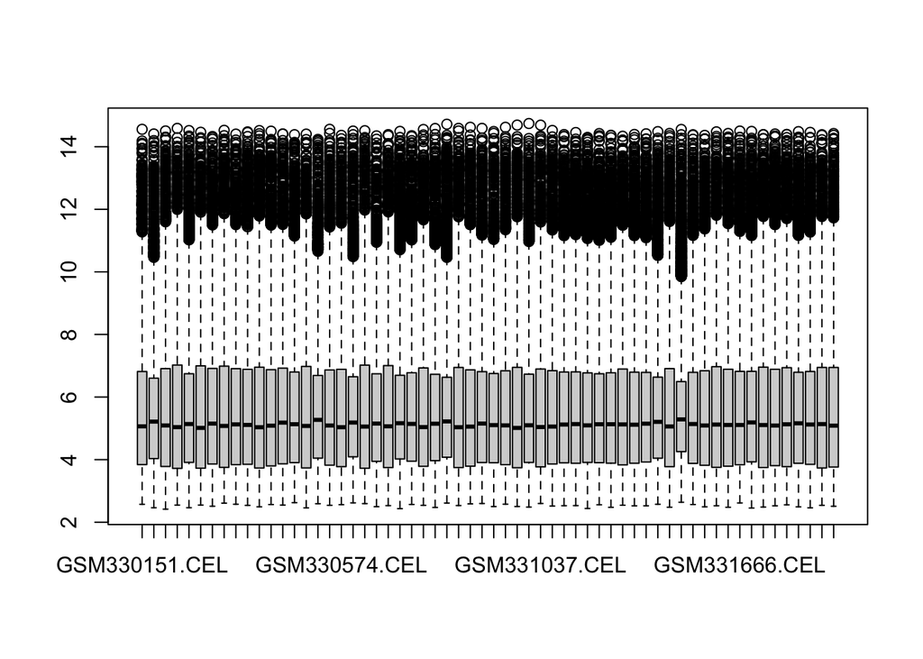

```r
boxplot(exprs(leukemiasEset))    # note different distributions across samples
```

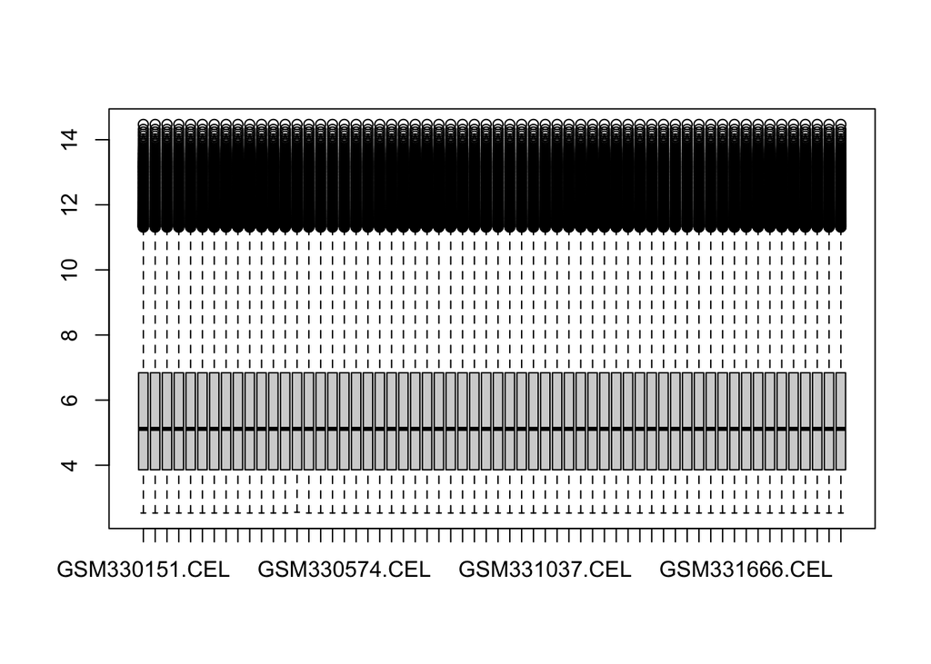

```r
lenorm = normalize.quantiles(exprs(leukemiasEset))    # quantile normalization
rownames(lenorm) = rownames(exprs(leukemiasEset))    # add row names
colnames(lenorm) = colnames(exprs(leukemiasEset))    # add column names
exprs(leukemiasEset) = lenorm    # overwrite initial exprs
boxplot(exprs(leukemiasEset))    # all samples are quantile normalized
```

Subset the leukemiasEset data to include only samples from chronic myeloid leukemia, CML (“CML”), and normal samples (“NoL”) into a new ExpressionSet, cml_normal:

```r
cml_normal = leukemiasEset[, leukemiasEset$LeukemiaType %in% c("CML", "NoL")]
cml_normal$LeukemiaType = factor(cml_normal$LeukemiaType)
```

The reference level for a factor is always the first listed level of the factor. By default, factors are ordered alphabetically. We want to find fold changes in genes between normal samples and CML samples, so we set the reference level to be our normal samples:

```r
cml_normal$LeukemiaType = relevel(cml_normal$LeukemiaType, "NoL")
factor(cml_normal$LeukemiaType)    # levels are now NoL, CML
```

```
##  [1] CML CML CML CML CML CML CML CML CML CML CML CML NoL NoL NoL NoL NoL NoL NoL
## [20] NoL NoL NoL NoL NoL
## Levels: NoL CML
```

Note that the feature data is currently empty except for row names, which are ENSEMBL IDs. This code maps the ENSEMBL IDs to gene symbols and ENTREZ IDs and adds them to the feature data for later analysis:

```r
library(org.Hs.eg.db)
symbols = mapIds(org.Hs.eg.db, rownames(cml_normal), keytype = "ENSEMBL", column="SYMBOL")
ids = mapIds(org.Hs.eg.db, rownames(cml_normal), keytype = "ENSEMBL", column="ENTREZID")
fData(cml_normal)$symbol = symbols
fData(cml_normal)$gene_id = ids
fData(cml_normal)
```

[output not shown]

[output cut: 20118 more lines]

```
## ENSG00000248029            <NA>      <NA>
## ENSG00000248042            <NA>      <NA>
## ENSG00000248048            <NA>      <NA>
## ENSG00000248049         UBA6-DT    550112
## ENSG00000248058            <NA>      <NA>
## ENSG00000248059            <NA>      <NA>
## ENSG00000248072            <NA>      <NA>
## ENSG00000248077            <NA>      <NA>
## ENSG00000248079            <NA>      <NA>
## ENSG00000248085            <NA>      <NA>
## ENSG00000248087            <NA>      <NA>
## ENSG00000248094            <NA>      <NA>
## ENSG00000248095            <NA>      <NA>
## ENSG00000248098          BCKDHA       593
## ENSG00000248099           INSL3      3640
```

## Q1: Simple t-tests for differentially expressed genes

```r
library(genefilter)
rtt=rowttests(exprs(cml_normal),cml_normal$LeukemiaType)
sum(rtt$p.value < 0.05)
```

```
## [1] 7937
```

```r
library(qvalue)
qv = qvalue(rtt$p.value)$qvalue
sum(qv < 0.05)
```

```
## [1] 7931
```

## Q2: Relationship between p-values and q-values

Recall that the q-value gives the proportion of observations at or below that q-value that are expected to be false positives.

```r
df = data.frame(p = rtt$p.value, q = qv)
df = df[rev(order(df$p)),]     # order by decreasing p-value
df_pt05 = df[df$p < .05,]    # keep only p-values below .05

df_pt05$q[1] # q-value corresponds to a p-value of .05 in this analysis
```

```
## [1] 0.05013847
```

```r
sum(rtt$p.value < .05) * df_pt05$q[1] # the number of genes in this dataset with a p-value below .05 exepected to be false positives
```

```
## [1] 397.9491
```

## Q3: Moderated t-tests with limma

Use the limma package to find which genes are differentially expressed between CML and normal bone marrow.

Inspect the p-values from the empirical Bayes moderated t-tests. Then, use the qvalue library to calculate the q-values for the p-values from the empirical Bayes model.

```r
library(limma)
fit <- lmFit(cml_normal, design=model.matrix(~ cml_normal$LeukemiaType))
colnames(coef(fit))
```

```
## [1] "(Intercept)"                "cml_normal$LeukemiaTypeCML"
```

```r
fit <- eBayes(fit)

pvals = fit$p.value[,2]
sum(pvals < 1e-5)
```

```
## [1] 362
```

```r
qval = qvalue(pvals)$qvalue
sum(qval < 1e-5)
```

```
## [1] 55
```

## Q4: Top differentially expressed gene from moderated t-tests

```r
tt <- topTable(fit, coef=2)
tt
```

```
##                   symbol gene_id     logFC   AveExpr         t      P.Value
## ENSG00000140968     IRF8    3394 -2.299714  8.345804 -14.25889 2.390021e-13
## ENSG00000223865 HLA-DPB1    3115 -2.221599 10.448588 -12.62060 3.348123e-12
## ENSG00000204287  HLA-DRA    3122 -2.289131  9.914416 -11.17477 4.291676e-11
## ENSG00000112799     LY86    9450 -2.150235  7.489614 -10.55819 1.366552e-10
## ENSG00000182718    ANXA2     302 -2.095449  9.344938 -10.55320 1.379654e-10
## ENSG00000242574  HLA-DMB    3109 -2.284026  8.172724 -10.44341 1.703743e-10
## ENSG00000196126 HLA-DRB1    3123 -2.114517 10.649954 -10.35594 2.017651e-10
## ENSG00000110077   MS4A6A   64231 -2.172877  7.995070 -10.33035 2.120397e-10
## ENSG00000231389 HLA-DPA1    3113 -1.902659  9.090147 -10.21328 2.663812e-10
## ENSG00000213316    LTC4S    4056  2.058185  6.403441  10.17865 2.850699e-10
##                    adj.P.Val        B
## ENSG00000140968 4.821149e-09 19.87494
## ENSG00000223865 3.376917e-08 17.54371
## ENSG00000204287 2.885723e-07 15.22919
## ENSG00000112799 5.346581e-07 14.16115
## ENSG00000182718 5.346581e-07 14.15231
## ENSG00000242574 5.346581e-07 13.95669
## ENSG00000196126 5.346581e-07 13.79968
## ENSG00000110077 5.346581e-07 13.75353
## ENSG00000231389 5.750429e-07 13.54132
## ENSG00000213316 5.750429e-07 13.47818
```

```r
tt[which.min(tt$adj.P.Val),] # gene with lowest adjusted p-value
```

```
##                 symbol gene_id     logFC  AveExpr         t      P.Value
## ENSG00000140968   IRF8    3394 -2.299714 8.345804 -14.25889 2.390021e-13
##                    adj.P.Val        B
## ENSG00000140968 4.821149e-09 19.87494
```

## Q5: Gene set analysis: mapping ENTREZ IDs to GO pathways

Use org.Hs.egGO2EG from the org.Hs.eg.db library to map GO pathways to the ENTREZ IDs of genes in those pathways:

```r
# convert go2eg to vector and record lengths of gene sets
go2eg = as.list(org.Hs.egGO2EG)
govector = unlist(go2eg)
golengths = sapply(go2eg, length)

# match pathway gene IDs and split into a new list
idxvector = match(govector, fData(cml_normal)$gene_id)
idx = split(idxvector, rep(names(go2eg), golengths))
head(idx)    # list of GO pathways with corresponding gene IDs
```

```
## $`GO:0000002`
##  [1]  9310   449  1036  4355 16441 15803  4632  4235  4235  7870 12782 12782
## [13]  5690
##
## $`GO:0000003`
## [1]  8848  5657    NA 14767
##
## $`GO:0000009`
## [1]   819 14572
##
## $`GO:0000010`
## [1]  8970 11153
##
## $`GO:0000012`
##  [1]   655 17777 13281  4760  1215  2064  7309  7309   583   583   583 12361
## [13]    NA
##
## $`GO:0000014`
##  [1] 11786   312 13485   404   404  2560 12501 12501  9889  4170  9394
```

```r
# remove NAs and keep only gene sets with over 10 genes
idxclean = lapply(idx, function(x) x[!is.na(x)])
idxlengths = sapply(idxclean, length)
idxsub = idxclean[idxlengths > 10]
```

```r
process = idxsub$`GO:0000002`
idx = fData(cml_normal)$gene_id %in% process
cml_normal[idx,]
```

```
## ExpressionSet (storageMode: lockedEnvironment)
## assayData: 5 features, 24 samples
##   element names: exprs, se.exprs
## protocolData
##   sampleNames: GSM331377.CEL GSM331378.CEL ... GSM331677.CEL (24 total)
##   varLabels: ScanDate
##   varMetadata: labelDescription
## phenoData
##   sampleNames: GSM331377.CEL GSM331378.CEL ... GSM331677.CEL (24 total)
##   varLabels: Project Tissue ... Subtype (5 total)
##   varMetadata: labelDescription
## featureData
##   featureNames: ENSG00000108852 ENSG00000126067 ... ENSG00000168530 (5
##     total)
##   fvarLabels: symbol gene_id
##   fvarMetadata: labelDescription
## experimentData: use 'experimentData(object)'
## Annotation: genemapperhgu133plus2
```

```r
fData(cml_normal[idx,])$symbol
```

```
## [1] "MPP2"   "PSMB2"  "CDO1"   "ZNF235" "MYL1"
```

## Q6: Gene set enrichment analysis for a single gene set

Set the seed to 1, then use roast() to perform gene set enrichment analysis for the gene set GO:0034765.

```r
set.seed(1)
design <- model.matrix(~ cml_normal$LeukemiaType)

process = idxsub$`GO:0034765`
idx2 = fData(cml_normal)$gene_id %in% process
cml_normal[idx2,]
```

```
## ExpressionSet (storageMode: lockedEnvironment)
## assayData: 41 features, 24 samples
##   element names: exprs, se.exprs
## protocolData
##   sampleNames: GSM331377.CEL GSM331378.CEL ... GSM331677.CEL (24 total)
##   varLabels: ScanDate
##   varMetadata: labelDescription
## phenoData
##   sampleNames: GSM331377.CEL GSM331378.CEL ... GSM331677.CEL (24 total)
##   varLabels: Project Tissue ... Subtype (5 total)
##   varMetadata: labelDescription
## featureData
##   featureNames: ENSG00000011009 ENSG00000011132 ... ENSG00000213096 (41
##     total)
##   fvarLabels: symbol gene_id
##   fvarMetadata: labelDescription
## experimentData: use 'experimentData(object)'
## Annotation: genemapperhgu133plus2
```

```r
r1 <- roast(cml_normal, idx2, design)
r1
```

```
##          Active.Prop     P.Value
## Down       0.1951220 0.998499625
## Up         0.4146341 0.001750438
## UpOrDown   0.4146341 0.003500000
## Mixed      0.6097561 0.000500000
```

## Q7: Gene set enrichment analysis for multiple gene sets

Set the seed to 1 again, then use mroast() to perform gene set enrichment analysis for all gene sets.

```r
# set.seed(1)
# r2 <- mroast(cml_normal, idxsub, design)
# r2
#
# r2_up = r2[r2$Direction == "Up",]
# sum(r2_up$PValue < 0.05)
# nrow(r2[r2$Direction == "Up" & r2$PValue < .05,])
#
# r2_down = r2[r2$Direction == "Down",]
# sum(r2_down$PValue < 0.05)
# nrow(mr[mr$Direction == "Down" & mr$PValue < .05,])

set.seed(1)
r2 <- mroast(cml_normal, idxsub, design)

r2_up <- r2[r2$Direction == "Up", ]
sum(r2_up$PValue < 0.05)
```

```
## [1] 1565
```

```r
r2_down <- r2[r2$Direction == "Down", ]
sum(r2_down$PValue < 0.05)
```

```
## [1] 701
```

```r
nrow(r2_down[r2_down$PValue < 0.05, ])
```

```
## [1] 701
```